# AUTHOR: Shardul Patil

# Step 4:Count Plots of each Column

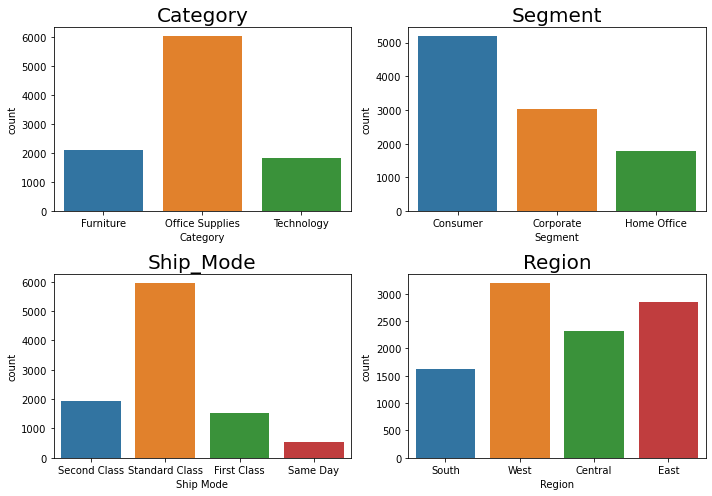

```python
fig,axs=plt.subplots(nrows=2,ncols=2,figsize=(10,7));
sns.countplot(df['Category'],ax=axs[0][0])
sns.countplot(df['Segment'],ax=axs[0][1])
sns.countplot(df['Ship Mode'],ax=axs[1][0])
sns.countplot(df['Region'],ax=axs[1][1])
axs[0][0].set_title('Category',fontsize=20)
axs[0][1].set_title('Segment',fontsize=20)
axs[1][0].set_title('Ship_Mode',fontsize=20)
axs[1][1].set_title('Region',fontsize=20)
plt.tight_layout()
```

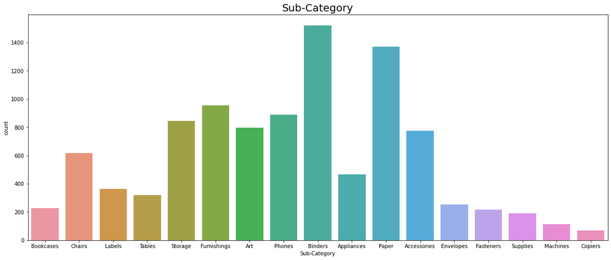

```python
plt.figure(figsize=(20,8))
sns.countplot(df['Sub-Category'])
plt.title('Sub-Category',fontsize=20)
```

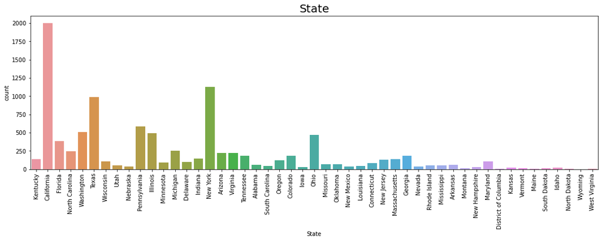

```python
plt.figure(figsize=(18,5))
sns.countplot(df['State'])
plt.xticks(rotation=90)
plt.title('State',fontsize=20)
```

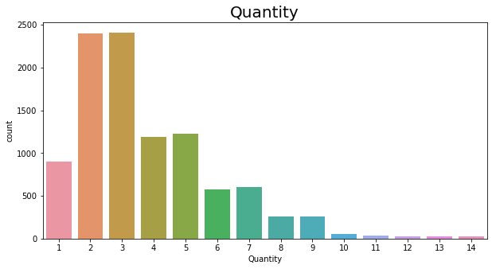

```python
plt.figure(figsize=(10,5))
sns.countplot(df['Quantity'])
plt.title('Quantity',fontsize=20)
```

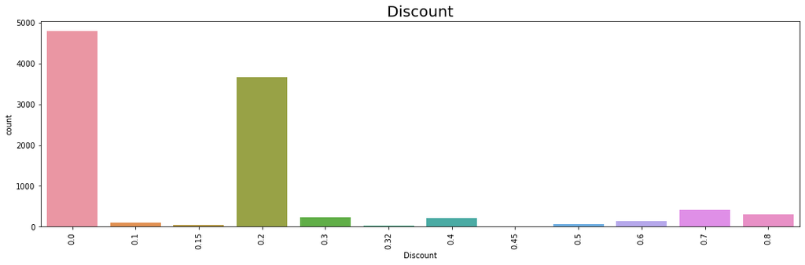

```python
plt.figure(figsize=(18,5))
sns.countplot(df['Discount'])
plt.xticks(rotation=90)
plt.title('Discount',fontsize=20)
```

# Step 5: Distribution Plot

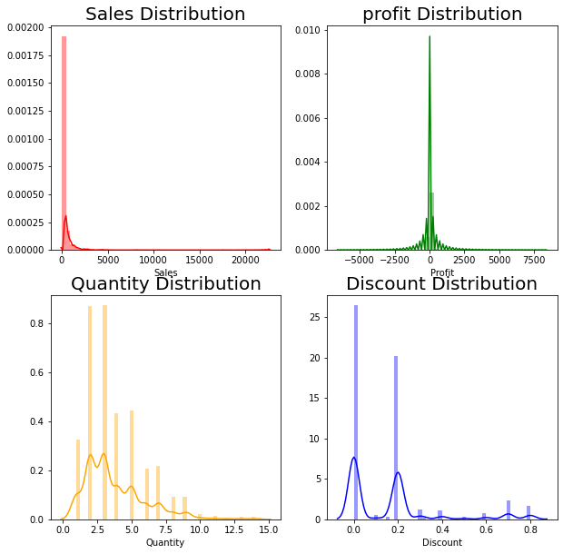

```python
fig,axs=plt.subplots(nrows=2,ncols=2,figsize=(10,10));
sns.distplot(df['Sales'],color='red',ax=axs[0][0])
sns.distplot(df['Profit'],color='green',ax=axs[0][1])
sns.distplot(df['Quantity'],color='orange',ax=axs[1][0])
sns.distplot(df['Discount'],color='blue',ax=axs[1][1])
axs[0][0].set_title('Sales Distribution',fontsize=20)
axs[0][1].set_title('profit Distribution',fontsize=20)
axs[1][0].set_title('Quantity Distribution',fontsize=20)
axs[1][1].set_title('Discount Distribution',fontsize=20)
plt.show()
```

# Step 6:Deal Analysis: State wise

```python
df['Country'].value_counts()
```

```
United States    9994
Name: Country, dtype: int64
```

# Only USA Country is here

```python
df1=df['State'].value_counts()
df1.head(10)
```

```
California        2001
New York          1128
Texas              985
Pennsylvania       587
Washington         506
Illinois           492
Ohio               469
Florida            383
Michigan           255
North Carolina     249
Name: State, dtype: int64
```

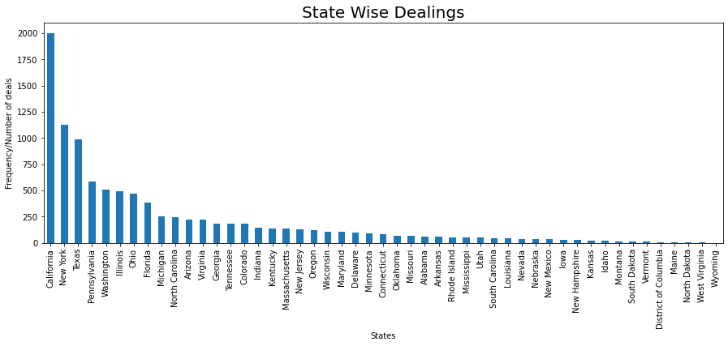

```python
df1.plot(kind='bar',figsize=(15,5))
plt.ylabel("Frequency/Number of deals")
plt.xlabel('States')
plt.title('State Wise Dealings',fontsize=20)
plt.show()
```

Here is top 3 States where deals are Highest: 1.california 2.New York 3.Texas Wyoming: Lowest Number of deals

```python
df['State'].value_counts().mean()
```

```
203.9591836734694
```

# Average number of deal per state is 204

# Step 7: Deal Analysis-City Wise

```python
df2=df['City'].value_counts()
df2=df2.head(50)
```

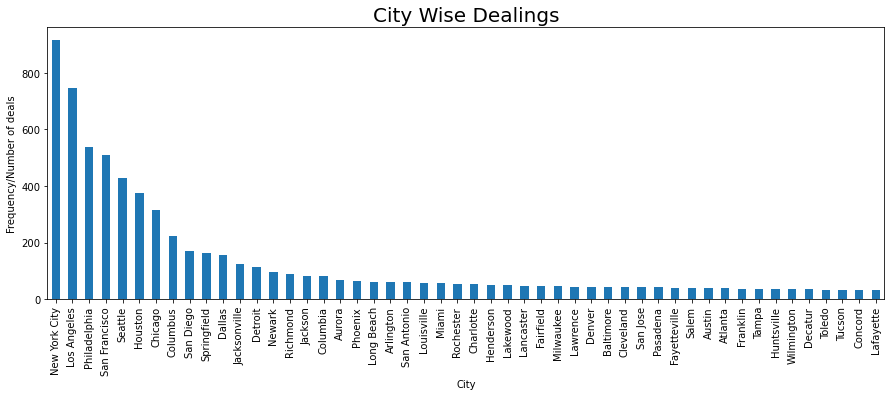

```python
df2.plot(kind='bar',figsize=(15,5))
plt.ylabel('Frequency/Number of deals')
plt.xlabel('City')
plt.title('City Wise Dealings',fontsize=20)
plt.show()
```

Here is top 3 city where deals are Highest 1.New York City 2.Los Angeles 3.Philadelphia

```python
df['City'].value_counts().mean()
```

```
18.821092278719398
```

# Average number of deals per city is 19

# Step 8: Segment wise analysis of Profit,Discount,Sale

```python
df['Segment'].value_counts()
```

```
Consumer       5191
Corporate      3020
Home Office    1783
Name: Segment, dtype: int64
```

```python
df_segment=df.groupby(['Segment'])[['Sales','Discount','Profit']].mean()
df_segment
```

| Segment | Sales | Discount | Profit |
| --- | --- | --- | --- |
| Consumer | 223.733644 | 0.158141 | 25.836873 |
| Corporate | 233.823300 | 0.158228 | 30.456667 |
| Home Office | 240.972041 | 0.147128 | 33.818664 |

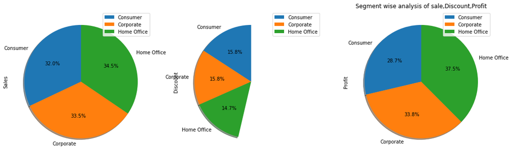

```python
#1.Sales 2.Discounts 3.profit
df_segment.plot.pie(subplots=True,autopct="%1.1f%%",figsize=(18,20),startangle=90,shadow=True,labels=df_segment.index)
plt.title('Segment wise analysis of sale,Discount,Profit')
```

# Step 9: State wise analysis of Profit,Discount,Sale

```python
df['State'].value_counts().head(10)
```

```
California        2001
New York          1128
Texas              985
Pennsylvania       587
Washington         506
Illinois           492
Ohio               469
Florida            383
Michigan           255
North Carolina     249
Name: State, dtype: int64
```

```python
df_state=df.groupby(['State'])[['Sales','Discount','Profit']].mean()
df_state.head(10)
```

| State | Sales | Discount | Profit |
| --- | --- | --- | --- |
| Alabama | 319.846557 | 0.000000 | 94.865989 |
| Arizona | 157.508933 | 0.303571 | -15.303235 |
| Arkansas | 194.635500 | 0.000000 | 66.811452 |
| California | 228.729451 | 0.072764 | 38.171608 |
| Colorado | 176.418231 | 0.316484 | -35.867351 |
| Connecticut | 163.223866 | 0.007317 | 42.823071 |
| Delaware | 285.948635 | 0.006250 | 103.930988 |
| District of Columbia | 286.502000 | 0.000000 | 105.958930 |
| Florida | 233.612815 | 0.299347 | -8.875461 |
| Georgia | 266.825217 | 0.000000 | 88.315453 |

# [1] State wise Profit Analysis

```python
df_state1=df_state.sort_values('Profit')
```

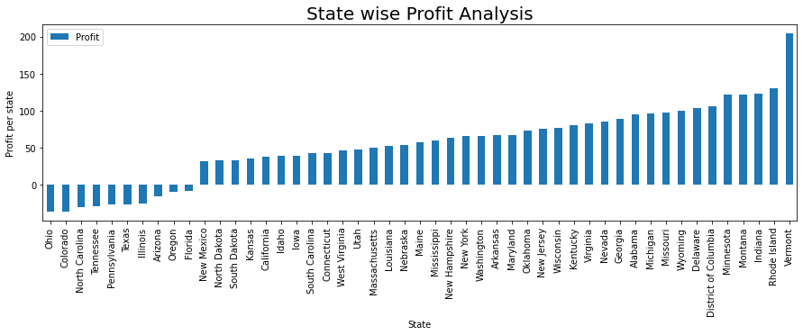

```python
df_state1[['Profit']].plot(kind='bar',figsize=(15,4))
plt.title('State wise Profit Analysis',fontsize=20)
plt.ylabel('Profit per state')
plt.xlabel('State')
plt.show()
```

Vermont : Highest Profit Ohio: LowestProfit

# [2] State wise sale Analysis

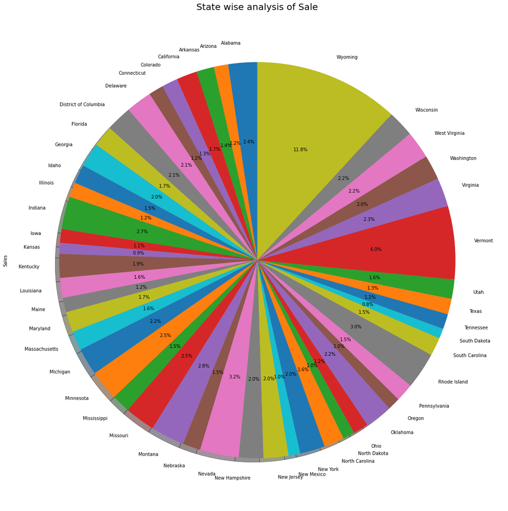

```python
df_state['Sales'].plot(kind='pie',figsize=(20,20),autopct='%1.1f%%',startangle=90,shadow=True)
plt.title('State wise analysis of Sale',fontsize=20)
```

Highest amount of sales=Wyoming (11.8%)

Lowest amount of sales=South Dakota(0.8%)

# [3] State wise Discount Analysis

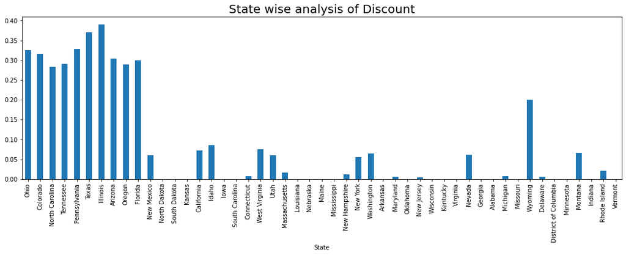

```python
df_state1['Discount'].plot(kind='bar',figsize=(18,5))
plt.title('State wise analysis of Discount',fontsize=20)
```

Illinois at the top

# Step 10: City Wise Analysis of Profit

```python
df_city=df.groupby(['City'])[['Sales','Discount','Profit']].mean()
df_city=df_city.sort_values('Profit')
df_city.head()
```

| City | Sales | Discount | Profit |
| --- | --- | --- | --- |
| Bethlehem | 337.926800 | 0.380000 | -200.619160 |
| Champaign | 151.960000 | 0.600000 | -182.352000 |
| Oswego | 107.326000 | 0.600000 | -178.709200 |
| Round Rock | 693.436114 | 0.274286 | -169.061614 |
| Lancaster | 215.031826 | 0.315217 | -157.371052 |

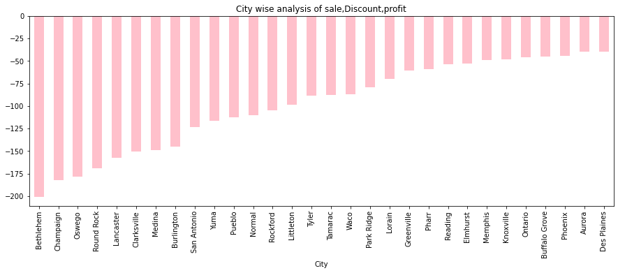

```python
#1.Low Profit
df_city['Profit'].head(30).plot(kind='bar',figsize=(15,5),color='Pink')
plt.title('City wise analysis of sale,Discount,profit')
```

30 city which has less profit

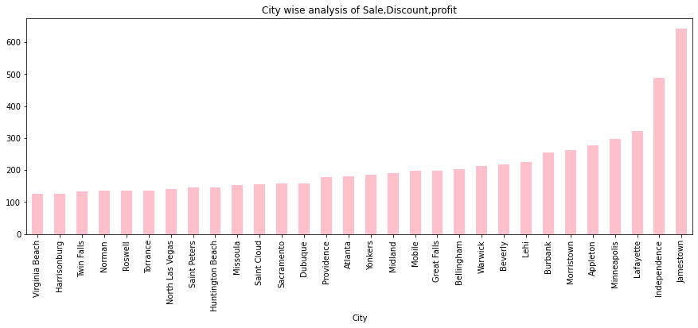

```python
#2. High Profit
df_city['Profit'].tail(30).plot(kind='bar',figsize=(15,5),color='Pink')
plt.title('City wise analysis of Sale,Discount,profit')
```

30 city which has high profit

```python
df_quantity=df.groupby(['Quantity'])[['Sales','Discount','Profit']].mean()
df_quantity.head(10)
```

| Quantity | Sales | Discount | Profit |
| --- | --- | --- | --- |
| 1 | 59.234632 | 0.152959 | 8.276396 |
| 2 | 120.354488 | 0.154858 | 16.006831 |
| 3 | 175.201578 | 0.153329 | 23.667715 |
| 4 | 271.764059 | 0.157708 | 37.131310 |
| 5 | 337.936339 | 0.157146 | 40.257394 |
| 6 | 362.101960 | 0.166556 | 18.051517 |
| 7 | 395.888393 | 0.161980 | 56.579163 |
| 8 | 458.210802 | 0.171595 | 42.244342 |
| 9 | 498.083683 | 0.147946 | 68.557716 |
| 10 | 422.046737 | 0.190702 | 35.862404 |

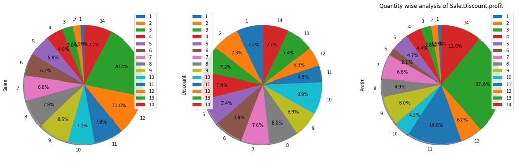

```python
#1. Sales 2.Discount 3.Profit
df_quantity.plot.pie(subplots=True,autopct="%1.1f%%",figsize=(20,20),pctdistance=0.69,startangle=90,shadow=True,labels=df_quantity.index)
plt.title('Quantity wise analysis of Sale,Discount,profit')
```

13 Number of Quantity is high for sales and Profit

# step 12:Category wise sales,Discount,Profit analyse

```python
df_category=df.groupby(['Category'])[['Sales','Discount','Profit']].mean()
df_category
```

| Category | Sales | Discount | Profit |
| --- | --- | --- | --- |
| Furniture | 349.834887 | 0.173923 | 8.699327 |
| Office Supplies | 119.324101 | 0.157285 | 20.327050 |
| Technology | 452.709276 | 0.132323 | 78.752002 |

```
array([<matplotlib.axes._subplots.AxesSubplot object at 0x1362E598>,
      dtype=object)
```

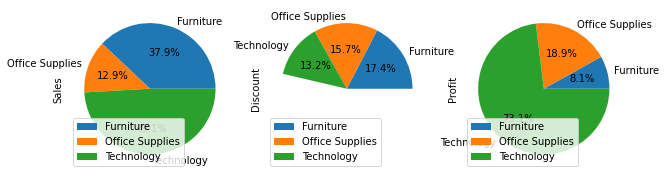

```python
df_category.plot.pie(subplots=True,figsize=(10,20),autopct='%1.1f%%',labels=df_category.index)
```

Maximum Sales and Profit obtain in Technology

Minimum profit obtain in furniture

# Step 13:Sub-Category wise sales,Profit and Discount

```python
df_sub_category=df.groupby(['Sub-Category'])[['Sales','Discount','Profit']].mean()
df_sub_category.head(10)
```

| Sub-Category | Sales | Discount | Profit |
| --- | --- | --- | --- |
| Accessories | 215.974604 | 0.078452 | 54.111788 |
| Appliances | 230.755710 | 0.166524 | 38.922758 |
| Art | 34.068834 | 0.074874 | 8.200737 |
| Binders | 133.560560 | 0.372292 | 19.843574 |
| Bookcases | 503.859633 | 0.211140 | -15.230509 |
| Chairs | 532.332420 | 0.170178 | 43.095894 |
| Copiers | 2198.941618 | 0.161765 | 817.909190 |
| Envelopes | 64.867724 | 0.080315 | 27.418019 |
| Fasteners | 13.936774 | 0.082028 | 4.375660 |
| Furnishings | 95.825668 | 0.138349 | 13.645918 |

# [1] based on sales

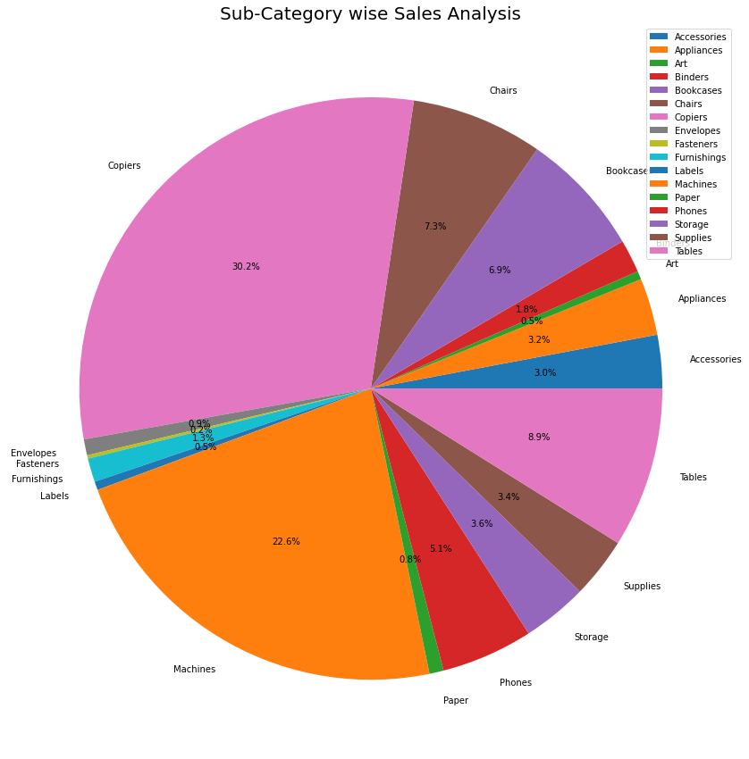

```python
plt.figure(figsize=(15,15))
plt.pie(df_sub_category['Sales'],labels=df_sub_category.index,autopct='%1.1f%%')
plt.title('Sub-Category wise Sales Analysis',fontsize=20)
plt.legend()
plt.xticks(rotation=90)
plt.show()
```

Copier then Machine have High Sales

# [2] Based on Discount

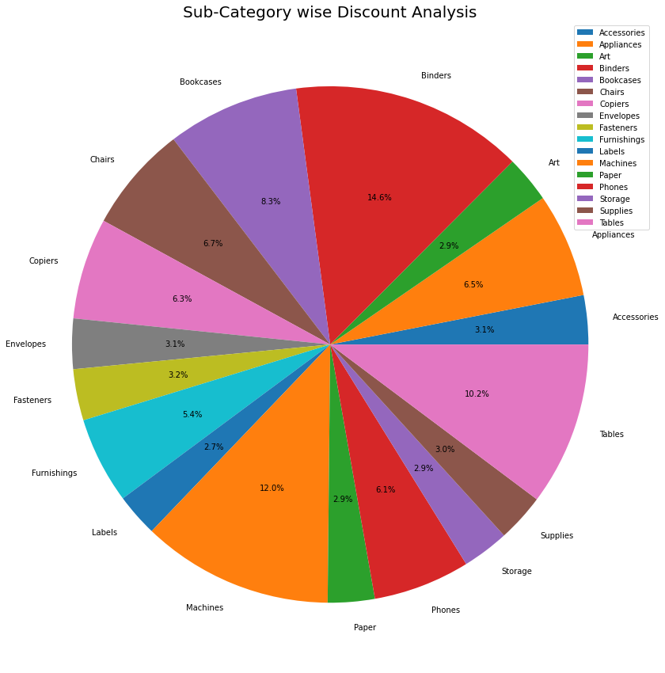

```python
plt.figure(figsize=(15,15))
plt.pie(df_sub_category['Discount'],labels=df_sub_category.index,autopct='%1.1f%%')
plt.title('Sub-Category wise Discount Analysis',fontsize=20)
plt.legend()
plt.xticks(rotation=90)
plt.show()
```

Binders,Machines and then tables have Discount.